# Lewiston Police Budgeting Overview v1

### Introduction

In an effort to better understand how Lewiston’s police budget compares to those in the rest of the state, I visualized the police budgets of select Maine towns. My initial data set contained the 12 most populous Maine towns, but due to difficulty obtaining strong data for 3 towns (Sanford, Scarborough and Saco), the final list of 9 towns became:

- Portland
- Lewiston
- Bangor
- South Portland
- Auburn
- Biddeford
- Brunswick
- Westbrook
- Augusta

All budget data was obtained via the respective town’s website, and all other data was found on census.gov.

For the sake of this project, the ‘budget’ is defined as a town’s municipal general fund expenses (without the school budget).

## Police Spending as a Percentage of Budget

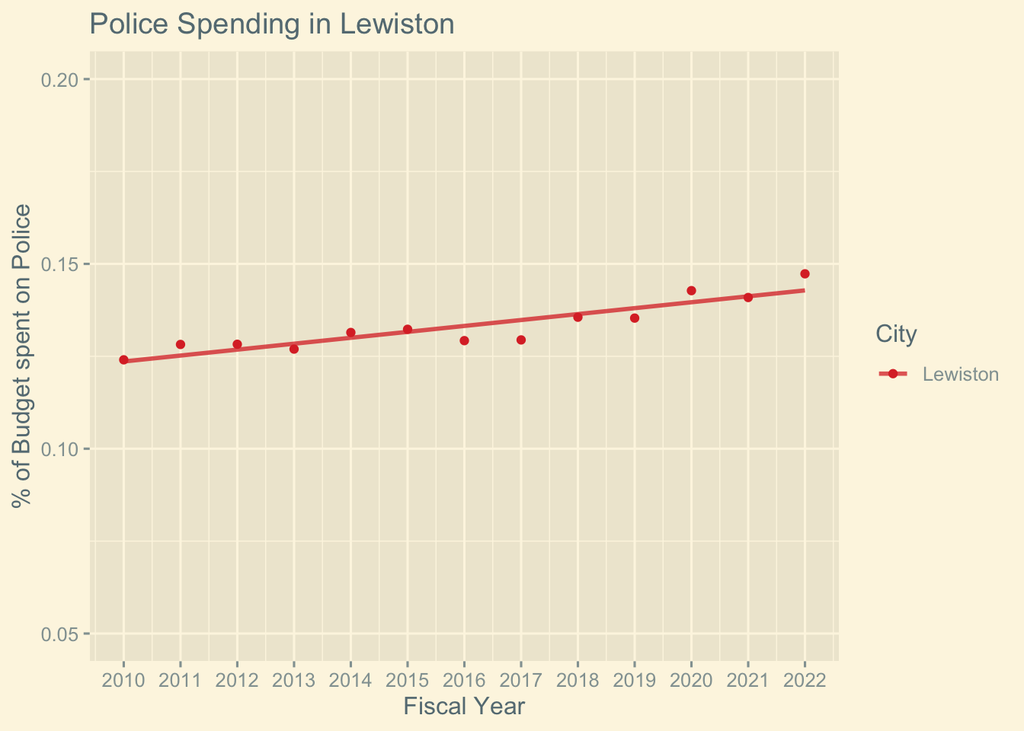

In this first plot, we see the percentages of Lewiston’s budget allocated to the police department from fiscal year 2010 to 2022. In FY 2010, 12.4% of the budget was allocated to the police and in FY 2022, 14.7%.

## Adding Other Towns for Context

### Portland

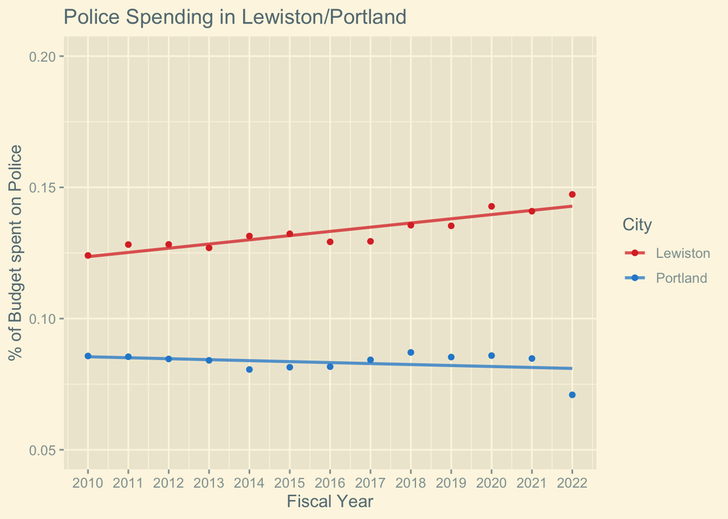

In order to better contextualize these percentages, we add other towns to the plot.

First, here is Lewiston’s spending as compared to Portland’s. Portland allocated 8.5% of their budget to police in FY 2010 and hovered around that mark for the rest of the decade. Notice the rather sharp decline in FY 2022 spending - down to 7%.

We can shrink our scope to fiscal years 2017-2022 to better highlight the opposite trajectories of Maine’s two most populous towns

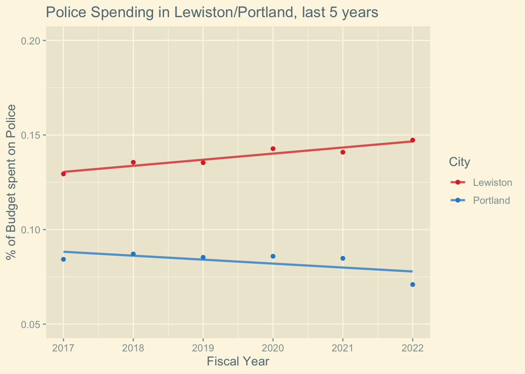

### Auburn

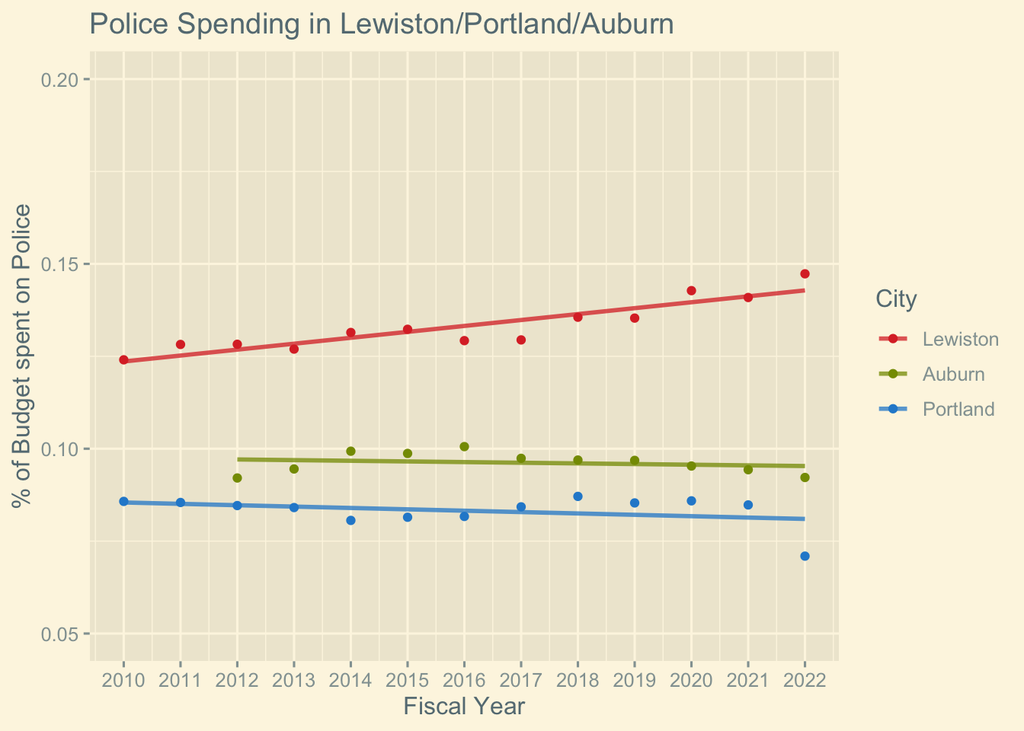

In Auburn, the difference is not as pronounced as the one with Portland.

Again, we reduce the scope to see a more recent picture

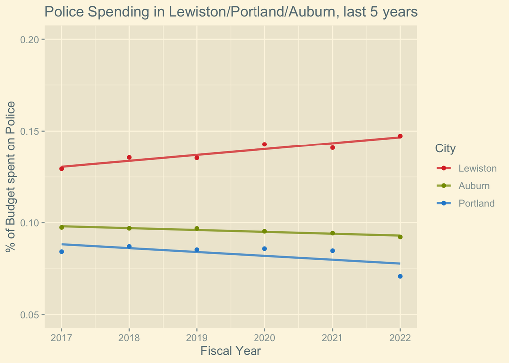

### Brunswick

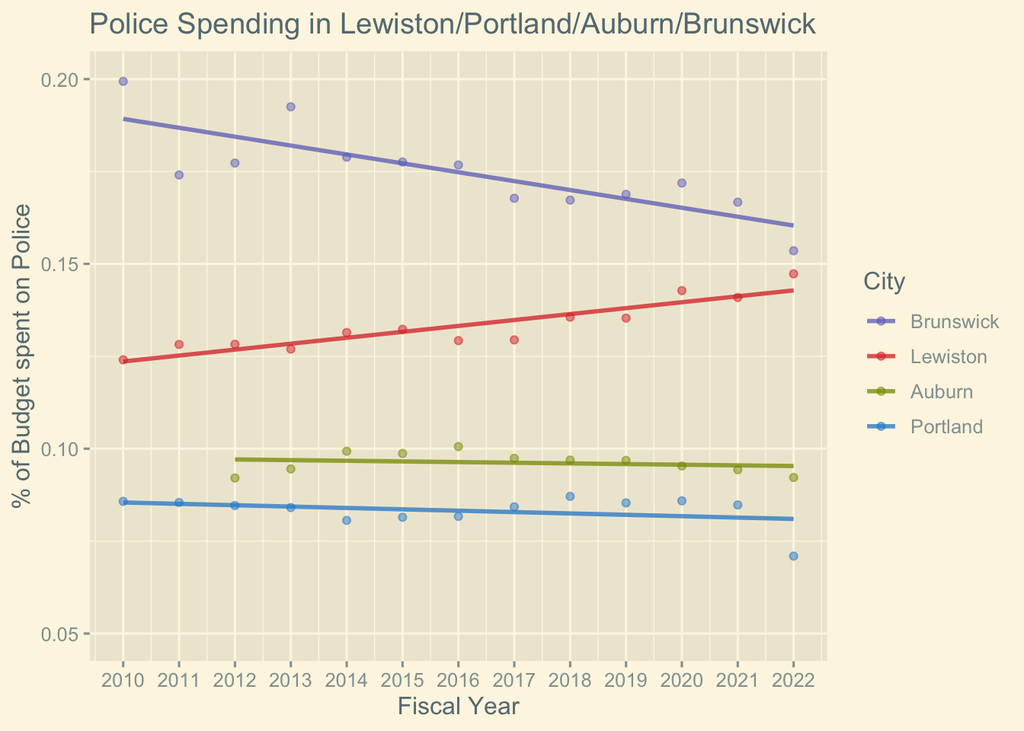

In introducing Brunswick to the plot we see our highest value yet - 19.9% in FY 2010. However over the course of the last 12 years, the spending has been reduced down to 15.3% in FY 2022. 0.6% higher than Lewiston.

The reduced scope brings into focus the contrast between Lewiston’s upward trajectory and the other town’s downward trajectories.

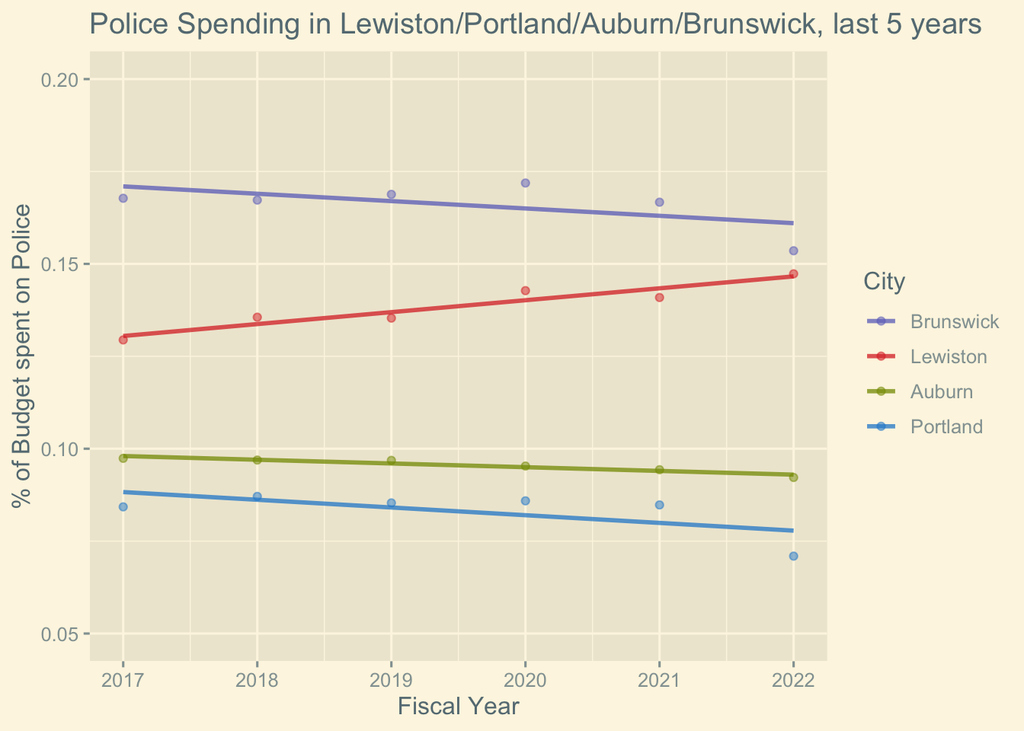

## Spending Trajectories

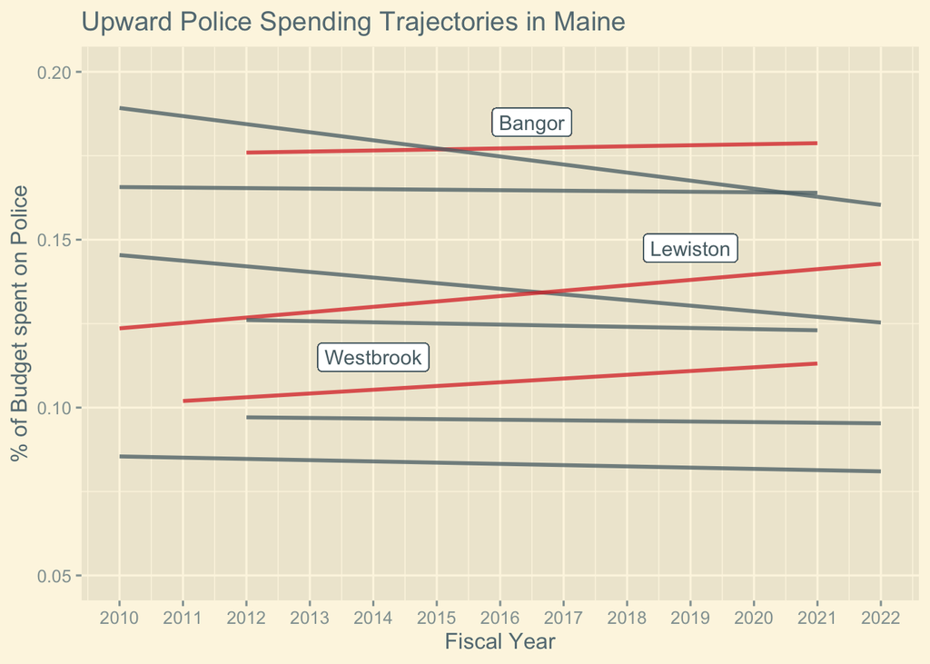

Of the 9 cities in the data set, 3 of them have upward spending trajectories by percentage - Westbrook, Bangor & Lewiston.

When the scope is reduced, 2 others join the fray - Augusta and South Portland

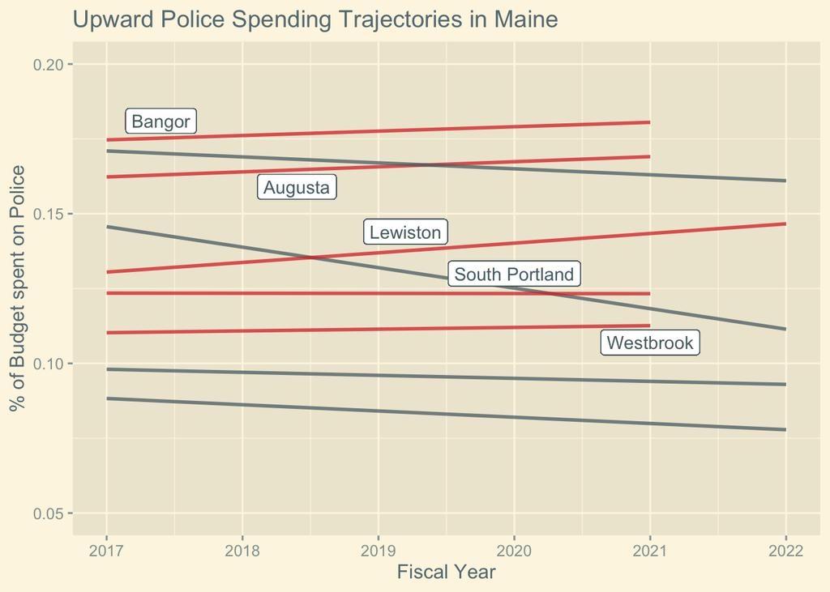

In an effort to better illustrate the slope of these trajectory lines, I subtracted each FY 2021 budget percentage by the FY 2012 budget percentage for each town and plotted the values.

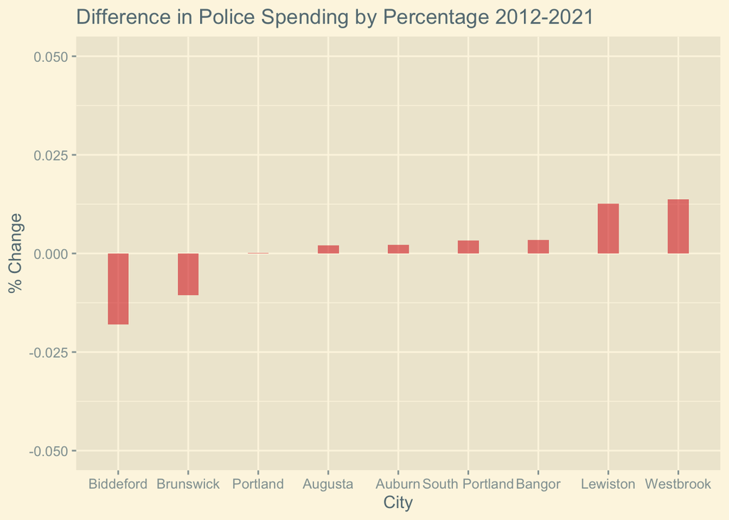

Here it is with the FY 2017-2021 scope. Here we see Lewiston with the steepest increase in police spending as a percentage of the budget over this timespan.

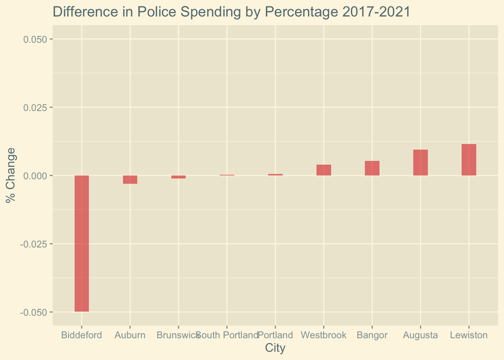

## Police Spending Per Citizen

Another way to analyze police spending is to calculate the dollars spent per citizen. Here’s a graph of Lewiston’s police dollars spent per citizen.

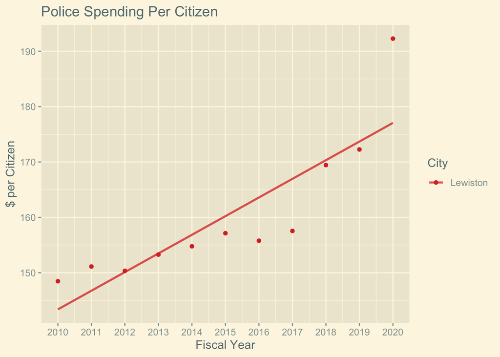

When adding in the 3 other towns from our earlier graph - Portland, Auburn & Brunswick - we see Lewiston at the bottom.

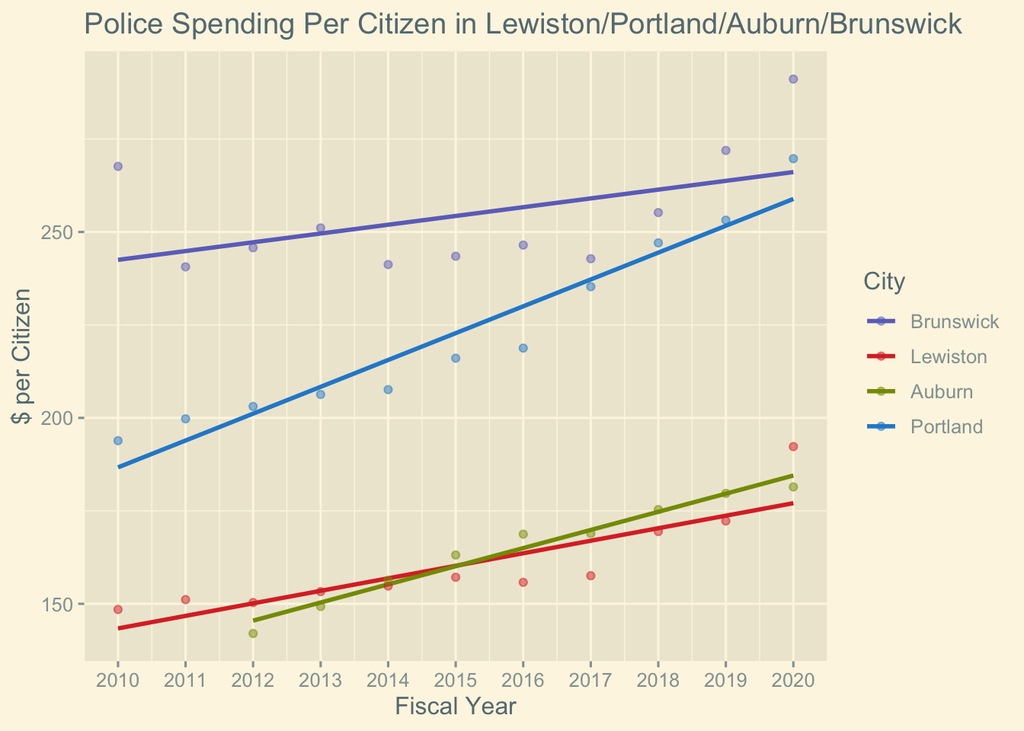

In an effort to control for the differing income levels between towns, I plotted the dollar per citizen value divided by the median household income for each town and plotted those values. We can see Lewiston in the middle of this graph.

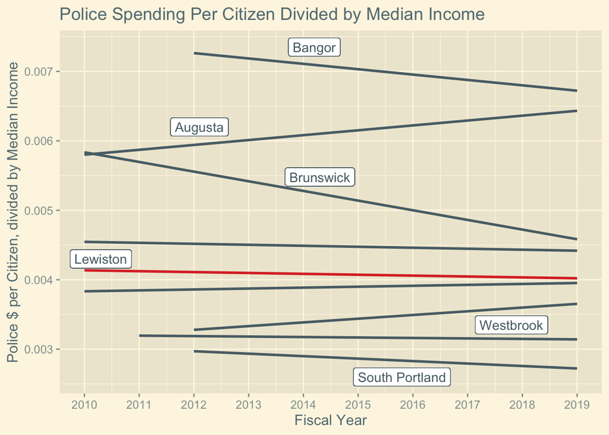